# FSS (Federal Signal) 기업 분석 보고서

Alpha Hunter Hidden Gem Week 2 — 미국 시정부 인프라 장비 독점

Author

Alpha Hunter × Chimera AI

Published

April 30, 2026

# 기업 개요

| 항목 | 내용 |
| --- | --- |
| **종목명** | Federal Signal Corporation (FSS, NYSE) |
| **업종** | Industrials / 환경 솔루션 & 안전 장비 |
| **핵심 사업** | 시정부·산업용 환경 장비(진공트럭, 스트리트스위퍼) 제조·판매 |
| **시총** | $7.4B (약 10.4조원) |
| **현재가** | $121.48 |
| **PER (TTM/Fwd)** | 27.6x / 22.4x |
| **PBR** | ~5.4x |
| **배당수익률** | 0.49% |
| **컨센서스** | Buy (매수 5 / 중립 1 / 매도 0) |
| **목표가** | $125 ~ $150 (평균 $138) |

**핵심 투자 포인트**

미국 시정부 환경 인프라 장비 1위. Q1 2026 EPS $1.18 (+55% YoY, 컨센서스 32% 상회). 매출 $626M (+35%). FY2026 가이던스 상향. **AROC 성공 패턴 재현 — 인프라 독점 + 가동률 극대화 + 배당 + 성장.**

## 0.1 사업 요약

Federal Signal은 **미국 최대 시정부·산업용 환경 장비 기업**이다. 도로 청소차, 하수관 청소 진공트럭, 덤프 트레일러 등을 제조·판매하며, 안전·보안 시스템(경고등, 사이렌)도 공급.

- **Environmental Solutions Group (ESG)** — 매출의 85%+. 진공트럭, 스위퍼, 덤프바디 등
- **Safety & Security Systems (SSG)** — 긴급차량 경고등, 산업 사이렌, 경고 시스템
- **“Power of the Platform”** 전략 — M&A + 교차판매 + 원가 시너지
- **Q1 2026** — 어제(4/29) 발표, 전 부문 기록적 실적

## 0.2 왜 히든젬인가? — AROC 패턴 분석

| AROC 패턴 | FSS 적용 |
| --- | --- |
| 인프라 독점 | 미국 시정부 환경장비 시장 1위, 높은 고객 전환비용 |
| 가동률 극대화 | 기록적 수주잔고, 유기적 성장 15% + 인수 효과 20% |
| 배당 + 성장 | 배당 0.49% + 매출 35% 성장 동시 달성 |
| 장기 계약 기반 | 시정부 예산 기반 반복 구매, 교체 사이클 수혜 |

# 1 실적 분석

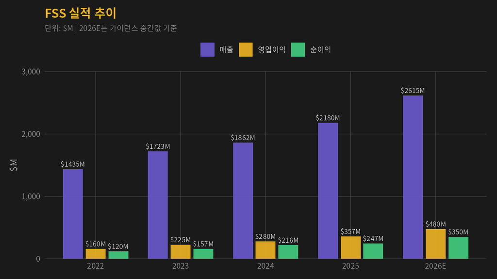

Figure 1: FSS 매출·영업이익·순이익 추이

## 1.1 핵심 재무 지표

| 지표 | 2022 | 2023 | 2024 | 2025 | 2026E |
| --- | --- | --- | --- | --- | --- |
| 매출 | $1,435M | $1,723M | $1,862M | $2,180M | **$2,615M** |
| 영업이익 | $160M | $225M | $280M | $357M | **$480M** |
| 영업이익률 | 11.1% | 13.1% | 15.0% | 16.4% | **18.4%** |
| 순이익 | $120M | $157M | $216M | $247M | **$350M** |
| EBITDA | $216M | $283M | $342M | $419M | **$540M** |

## 1.2 Q1 2026 서프라이즈 (4/29 발표)

| 항목 | 실적 | 컨센서스 | 서프라이즈 |
| --- | --- | --- | --- |
| EPS (adj.) | **$1.18** | $0.89 | **+32.6%** |
| 매출 | **$626M** | ~$530M | **+18%** |
| 영업이익 | **$100M** | ~$75M | **+33%** |
| EBITDA 마진 | **20.2%** | ~18% | +220bps |

## 1.3 성장성 분석

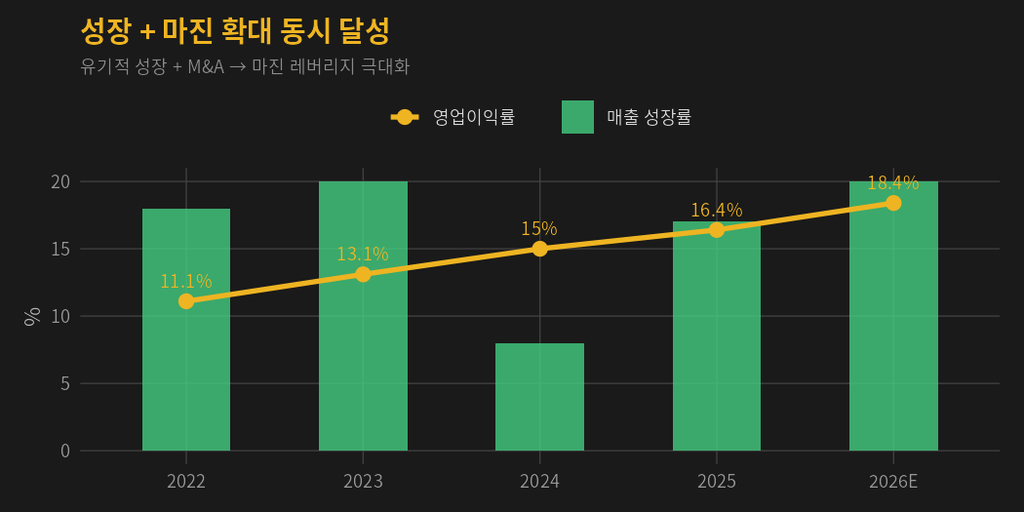

Figure 2: 매출 성장률 vs 영업이익률 추이

**인사이트**

4년간 영업이익률이 11% → 18%로 꾸준히 확대. M&A 시너지 + “Power of the Platform” 전략이 가동률과 교차판매를 극대화. AROC의 고정비 레버리지 패턴과 동일한 궤적.

## 1.4 세그먼트 분석

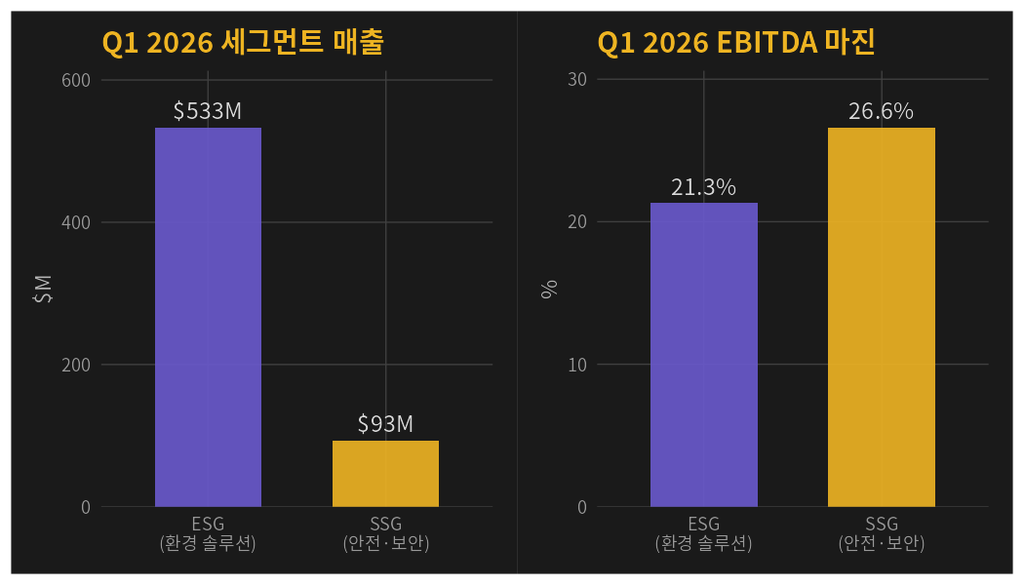

Figure 3: Q1 2026 세그먼트별 실적

- **ESG** — 매출 $533M (+38% YoY), EBITDA 마진 21.3% (+130bps)
- **SSG** — 매출 $93M (+22% YoY), EBITDA 마진 26.6% (+460bps)
- SSG의 마진 확대가 특히 인상적 — 고마진 안전장비 수요 급증

# 2 카탈리스트

# 3 리스크 분석

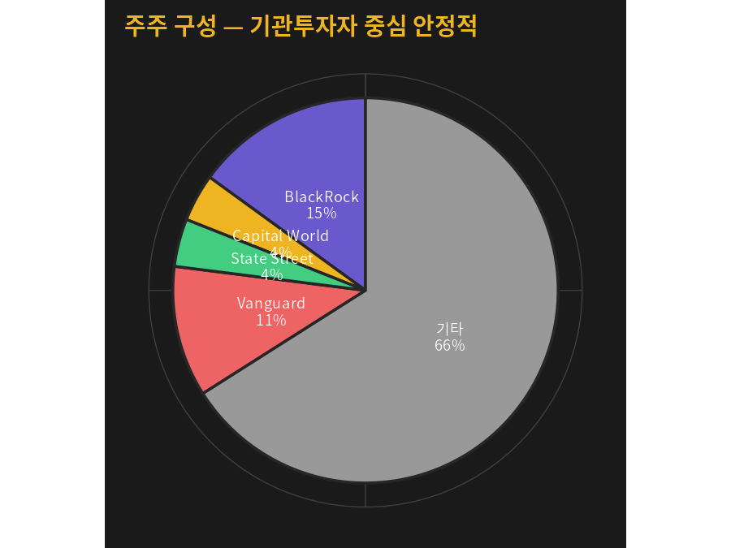

Figure 4: FSS 주주 구성

## 3.1 주요 리스크

- **M&A 통합 리스크** — 빈번한 인수에 따른 통합 실패 가능성
- **시정부 예산 의존** — 지방정부 재정 악화 시 장비 구매 지연
- **부채 $595M** — D/E 40.6%, M&A 자금 조달에 따른 레버리지
- **밸류에이션** — Fwd PE 22.4x, 산업재 섹터 평균 대비 프리미엄
- **원자재 가격** — 철강 등 원자재 가격 상승 시 마진 압박

# 4 투자자 렌즈 분석

## 4.1 워런 버핏 — “경제적 해자 + 가치”

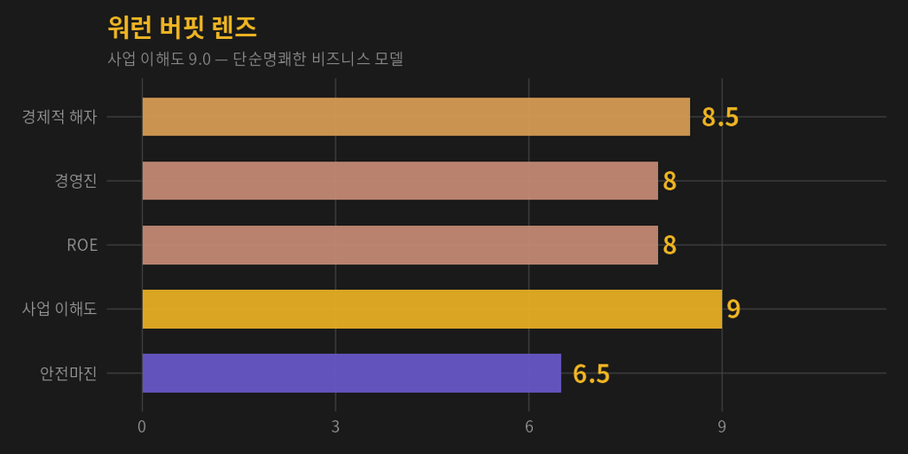

Figure 5: 워런 버핏 렌즈 평가

| 항목 | 점수 | 평가 |
| --- | --- | --- |
| 경제적 해자 | **8.5** | 시정부 장비 시장 1위, 높은 전환비용, 브랜드 충성도 |
| 경영진 | 8.0 | “Power of the Platform” M&A 전략 성공적 실행 |
| ROE | 8.0 | 20.5% — 자본 효율성 우수 |
| 사업 이해도 | **9.0** | “도로 청소차 만드는 회사” — 매우 단순 |
| 안전마진 | 6.5 | Fwd PE 22x — 성장 감안하면 합리적이나 할인은 아님 |

> 버핏 총평: “누구나 이해할 수 있는 사업. 시정부는 도로를 청소해야 하고, FSS가 그 장비를 만든다. 단순하고 반복적인 수요.”

## 4.2 피터 린치 — “10배 주식 가능성”

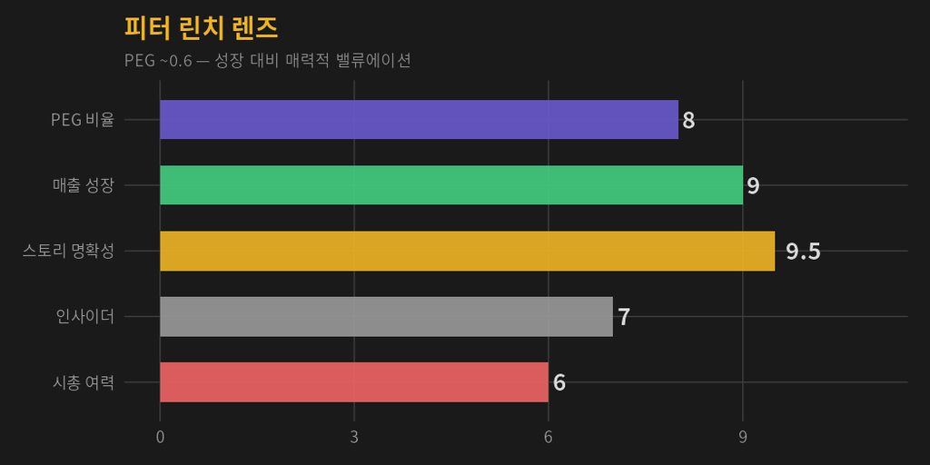

Figure 6: 피터 린치 렌즈 — 10배 주식 점검

| 항목 | 수치 | 평가 |
| --- | --- | --- |
| PEG 비율 | **~0.6** | Fwd PE 22 / 성장률 35% — 매우 매력적 |
| 매출 성장 | +35% YoY | Q1 2026 기록적 성장 |
| 스토리 | 명확 | “인프라 투자 확대 → 시정부 장비 수요 폭증” |
| 10배 가능성 | 보통 | 시총 $7.4B → $74B은 어려우나 **2~3배 ($250~$350) 가능** |

# 5 참고: 차선 후보 — STRL (Sterling Infrastructure)

| 항목 | STRL | FSS |
| --- | --- | --- |
| 시총 | $14.4B | $7.4B |
| 매출 성장 | +51.5% | +35% |
| 영업이익률 | 15.3% | 16.4% |
| 컨센서스 | **Strong Buy (1.0)** | Buy (1.67) |
| 배당 | 없음 | 0.49% |
| 핵심 | 데이터센터 인프라 | 시정부 환경장비 |
| Fwd PE | 29.5x | 22.4x |
| 비고 | 전원 Strong Buy, 백로그 $3B | Q1 서프라이즈, 가이던스 상향 |

STRL은 데이터센터 e-인프라 시장에서 123% 성장 중이나, 배당 미지급·높은 밸류에이션으로 AROC 패턴 적합도는 FSS가 우위.

# 6 종합 판정

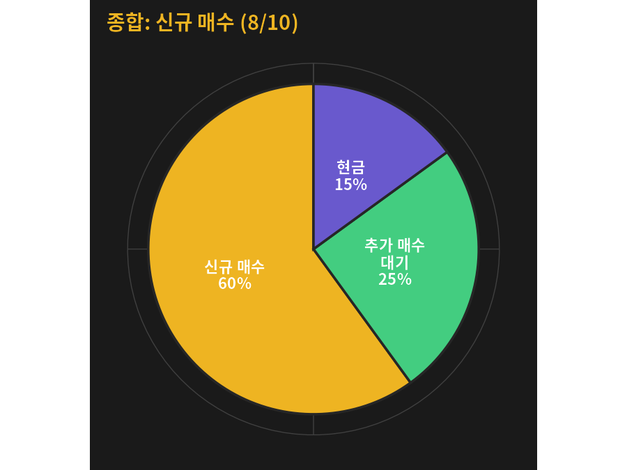

Figure 7: 투자 판정 — 신규 매수 추천

## 6.1 최종 판정: 신규 매수 추천

[output not shown]

**액션 플랜**

# 7 스크리닝 필터 통과 내역

[output not shown]

*이 보고서는 가상 투자 시뮬레이션 목적으로 작성되었습니다. 실제 투자 권유가 아닙니다. 모든 투자 결정은 개인의 판단과 책임 하에 이루어져야 합니다.*

*Alpha Hunter × Chimera AI | Vibe Investing Framework*